GeoStat Lab · Esercitazioni svolte

# Rumore bianco, AR(1) e random walk

M09_N10 · Borealis · soluzione eseguita e commentata

Tre curve possono avere lo stesso numero di osservazioni e dipendenze completamente diverse?

Sorgente R MarkdownCome eseguire il notebook

## Prima di iniziare

- Riconoscere tre meccanismi generativi.
- Verificare le equazioni del CSV.
- Distinguere traiettoria e processo.

**Prerequisiti.** Lettura di CSV, vettori, indicizzazione e funzioni di base in R. I blocchi vanno eseguiti nell’ordine all’interno del singolo notebook.

**Dati e unità.** Tre realizzazioni sintetiche di 300 passi, senza unità fisica. L’AR(1) del CSV ha coefficiente 0,65 e valore iniziale fissato a zero: all’inizio presenta un transitorio. Nel random walk il primo valore registrato è già diverso da zero: la prima riga non va confusa con un’eventuale condizione iniziale precedente. Le colonne x_VAR e y_VAR appartengono a un altro approfondimento e qui non vengono usate.

**Preparazione del progetto e seme casuale**

Aprire il progetto `GeoStat_Lab_Notebooks.Rproj` di Borealis oppure il progetto generale dei notebook. Il blocco individua `M09_Borealis` e carica sempre le sue funzioni, anche se la cartella di lavoro è quella del progetto generale. Dati e risultati appartengono a questo modulo.

R · codice commentato

```r
# Trova la cartella del modulo, anche dal progetto generale del corso.
.gs_cerca <- normalizePath(getwd(), winslash="/", mustWork=TRUE)
repeat {
  .gs_candidati <- c(.gs_cerca, file.path(.gs_cerca, "M09_Borealis"))
  .gs_ok <- file.exists(file.path(.gs_candidati, "M09_N01.Rmd")) &
    file.exists(file.path(.gs_candidati, "R", "funzioni_notebook.R"))
  if (any(.gs_ok)) {
    .gs_modulo <- .gs_candidati[which(.gs_ok)[1L]]
    break
  }
  .gs_padre <- dirname(.gs_cerca)
  if (.gs_padre == .gs_cerca) {
    stop("Aprire il progetto M09_Borealis o quello generale dei notebook.")
  }
  .gs_cerca <- .gs_padre
}
# Usa sempre le funzioni di questo modulo e i suoi dati.
source(file.path(.gs_modulo, "R", "funzioni_notebook.R"), local=TRUE)
.gs_funzioni <- .gs_prepara_notebook(.gs_modulo, "M09_N10")
carica_dati <- .gs_funzioni$carica_dati
percorso_dati <- .gs_funzioni$percorso_dati
percorso_risultati <- .gs_funzioni$percorso_risultati
options(width=88, digits=6)
# Il seme consente di ripetere le estrazioni casuali di questo notebook.
set.seed(9010)
```

## 1. Leggere le realizzazioni

Ogni colonna è una traiettoria simulata, non l’intero processo stocastico. L’AR(1) fornito inizia da zero, quindi la sua distribuzione iniziale non è quella stazionaria.

R · codice commentato

```r
p <- carica_dati("processi_simulati.csv")
stopifnot(nrow(p)==300L, !anyNA(p))
nomi <- c("rumore_bianco", "ar1", "random_walk")
head(p[c("passo",nomi)],4)
par(mfrow=c(3,1),mar=c(3.8,4.5,1.7,1.2))
for(n in nomi) plot(p$passo,p[[n]],type="l",col="#087C74",
 xlab="Passo",ylab=n)
```

Risultato dell’esecuzione

```
passo rumore_bianco        ar1 random_walk
1     1      0.231880  0.0000000   -0.722823
2     2      0.731884  0.7318843   -0.704263
3     3     -0.839262 -0.3635376   -1.348778
4     4      0.195051 -0.0412485   -2.313837
```

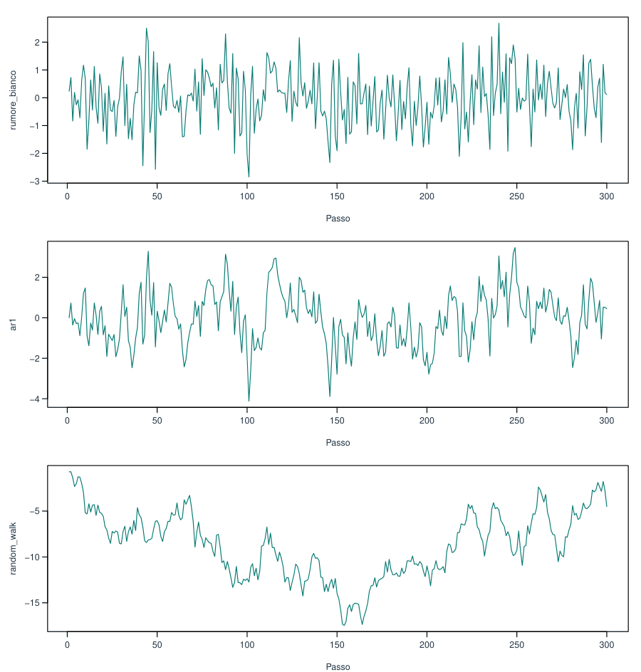

M09_N10 · Leggere le realizzazioni · grafico prodotto dal codice riportato sopra.

Lettura del risultato

Il rumore bianco fluttua rapidamente, l’AR(1) mostra persistenza e il random walk accumula gli incrementi. Queste sono osservazioni descrittive su traiettorie finite.

## 2. Controllare le equazioni

L’AR(1) soddisfa $x_t=0{,}65x_{t-1}+e_t$ usando la colonna rumore_bianco a partire dal secondo passo. Gli incrementi $w_t-w_{t-1}$ del random walk provengono da una sequenza diversa. Le prime posizioni vanno lette nel file.

R · codice commentato

```r
eps <- p$rumore_bianco[-1]
c(errore_AR=max(abs(tail(p$ar1,-1)-.65*head(p$ar1,-1)-eps)),
 scarto_incrementi_RW_da_eps=max(abs(diff(p$random_walk)-eps)),
 iniziale_AR=p$ar1[1],iniziale_RW=p$random_walk[1])
```

Risultato dell’esecuzione

```
errore_AR scarto_incrementi_RW_da_eps                 iniziale_AR
                1.15000e-08                 3.92086e+00                 0.00000e+00
                iniziale_RW
               -7.22823e-01
```

Lettura del risultato

L’equazione AR(1) coincide entro l’arrotondamento del CSV. Gli incrementi del random walk differiscono dalla colonna rumore_bianco. AR(1) e rumore_bianco condividono invece innovazioni, quindi quelle due colonne non sono campioni indipendenti.

## 3. Processo e singola traiettoria

Per un AR(1) con $|\phi|<1$, la varianza stazionaria è $\sigma_\varepsilon^2/(1-\phi^2)$. L’inizializzazione a zero si avvicina a questo equilibrio con il tempo. Una media campionaria non coincide necessariamente con l’attesa teorica.

R · codice commentato

```r
data.frame(serie=nomi,
 media=vapply(p[nomi],mean,numeric(1)),
 SD=vapply(p[nomi],sd,numeric(1)))
phi <- .65
c(varianza_equilibrio_innovazioni_unitarie=1/(1-phi^2),
 quota_transitorio_dopo_10=phi^(2*10))
```

Risultato dell’esecuzione

```
serie      media       SD
rumore_bianco rumore_bianco -0.0144399 0.991418
ar1                     ar1 -0.0462264 1.314284
random_walk     random_walk -8.6774223 3.607693
varianza_equilibrio_innovazioni_unitarie                quota_transitorio_dopo_10
                             1.731601732                              0.000181245
```

Lettura del risultato

La quota transitoria si riduce rapidamente con questo coefficiente. Nel random walk non compare un equilibrio analogo della varianza dei livelli.

## Variante svolta

Simulare un AR(1) che parta già dalla distribuzione stazionaria, con varianza uno.

R · codice commentato

```r
set.seed(1910)
z <- simula_ar1(300,phi=.7)
c(media=mean(z),varianza=var(z),ACF1=as.numeric(acf(z,plot=FALSE,lag.max=1)$acf[2]))
```

Risultato dell’esecuzione

```
media   varianza       ACF1
0.00395219 0.89097539 0.71340213
```

La funzione estrae il primo valore da N(0,1) e usa innovazioni con varianza 1−φ². I valori campionari oscillano attorno alle proprietà teoriche.

**Errore da riconoscere**

Dichiarare un processo stazionario soltanto perché una sua curva appare stabile, oppure ignorare l’inizializzazione finita del CSV.

## Risposta alla domanda

Numero di osservazioni e scala del grafico non determinano la dipendenza. Equazione generatrice e condizione iniziale chiariscono le differenze fra i tre casi.